# Branch Statistics analysis

Arslan Zaidi

3/15/2019

### Introduction

Here I calculate branch length statistics (BLS) from heteroplasmy data. This method allows one to estimate the amount of drift in heteroplasmies occurring at various stages of development. For example, take a look at the following phylogeny:

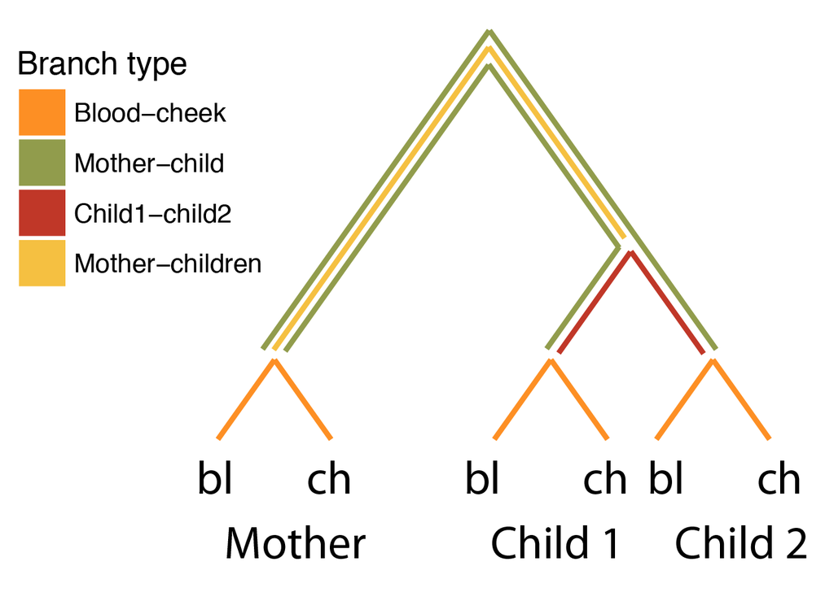

Fig.1: Assumed phylogeny for a mother-2children family

The tree represents the hypothesized relationship among samples from the same family. The blood and cheek samples from each person are “bl” and “ch” respectively. With the BLS approach, we can break the phylogeny down into a number of branches (represented with different colors) and estimate the amount of drift experienced by heteroplasmies during these stages of development. This notebook shows how we did this.

I will first calculate Fst (ratio of averages method) values for all pairwise comparisons in a family. Then use these to generate BLS.

First, load R libraries

```r
library(data.table)
library(ggplot2)
library(dplyr)
library(tidyr)
library(purrr)
library(kableExtra)
library(forcats)
library(KScorrect)
library(gridExtra)
library(ape)
```

### Data wrangling and annotation of heteroplasmies

Load heteroplasmy data and annotate heteroplasmies (e.g. which gene they are in, whether they are synonymous or non-synonymous, what is their pathogenecity score etc.). This will be useful for later when I need to compare BLS across different categories.

```r
#### load heteroplasmies - conservative (one mother and two children families only) #####
hq.counts<-fread("~/Documents/mtproj_files/M2_new/files/Database/Heteroplasmy_tables/hq_counts_adj_frequency_09272018.txt",
                 header=T)

#add unique identifiers to table
hq.counts<-hq.counts%>%
  mutate(individual_het_id=paste(hq.counts$individual_id,hq.counts$position,sep="_"),
         mother_het_id=paste(hq.counts$mother_id,hq.counts$position,sep="_"))

#select specific columns to keep. We don't need all of them.
hq<-hq.counts%>%
  select(FID,fam_cat,fam_het_id,mother_id,mot_cat,mother_het_id,individual_id,individual_het_id,tissue_id,position,level,tissue,major,minor,adj.f,cvrg,age_collection,age_birth)

##load annotations
annot<-fread("~/Documents/mtproj_files/M2_new/files/Analysis/syn_nsyn_annotation/hq_adjf_ancestral_syn_pathogenic_03222019.txt",header=T,sep="\t")

#group genes by functional class
annot<-annot%>%
  mutate(region=case_when(gene%in%c("TRNH","TRNL1","TRNW","TRNS2","TRNT","TRNP","TRNV","TRNQ","TRNM","TRNC","TRNK","TRNR","TRNI","TRNN","TRNF","TRND")~"TRNA",
                          gene%in%c("RNR1","RNR2")~"RNA",
                          gene%in%c("D-loop1","D-loop2")~"D-loop",
                          gene%in%c("ND3","ND4","ND5","ND6","CYTB","ND1","ND2","COX1","ATP8","ATP6","COX2","COX3")~"CDS",
                          gene%in%c("")~""))

#anotate heteroplasmies
hq<-annot%>%
  select(fam_het_id,region,gene,fold.d,syn,pathogenicity,ancestral.py,mutant.py)%>%
  distinct()%>%
  merge(hq,.,by="fam_het_id",all.x=T)
```

Wrangle the heteroplasmy data in a format that can be used to calculate Fst components automatically. Basically, I ‘connect’ each mother to her children and call this a family. Note that this way there may be multi-generational pedigrees thar are split into multiple families. This allows me to calculate branches for each family separately.

While we are at it, I am also going to extract the age information and add this to the heteroplasmy data. This will allow me to calculate BLS for different age groups.

```r
#divide data into two based on age at collection
q.age_collection<-hq%>%
  select(individual_id,age_collection)%>%
  distinct()%>%
  pull(age_collection)%>%
  quantile(.,probs=c(0,0.5,1))/365

#median age = 11.85

#mothers
hq.mothers<-hq%>%
  filter(mot_cat!="")%>%
  mutate(mother_group=individual_het_id,
         age_birth_cat=NA,
         age_collect_cat=cut(age_collection/365,breaks=q.age_collection,ordered_result=T,include.lowest=T))

#their children
hq.children<-hq%>%
  filter(mother_id%in%hq.mothers$individual_id)

#get age of mother at childbirth for these children
q.age_birth<-hq.children%>%
  select(mother_id,age_birth)%>%
  distinct()%>%
  pull(age_birth)%>%
  quantile(.,probs=c(0,0.5,1))/365

hq.children<-hq.children%>%
  mutate(mother_group=mother_het_id,
         age_birth_cat=cut(age_birth/365,breaks=q.age_birth,ordered_result=T,include.lowest=T),
         age_collect_cat=cut(age_collection/365,q.age_collection,ordered_result=T,include.lowest=T))

#rbind the two dataframes
hq.concat<-rbind(hq.mothers,hq.children)

#split hq data by mother_id
shq<-split(hq.concat,f=hq.concat$mother_group)
```

### Calculate Fst and Dxy (divergence)

Now I load functions that I wrote in a separate script to calculate Fst components, dxy (distance), and BLS. The scripts are able to generate different estimators of Fst (Hudson’s, Reynold’s, Weir-Cockerham etc.). I will use Hudson’s throughout as it is a more robust estimator (Bhatia et al. 2013).

```r
#load functions to calculate Fst and Branch statistics
source("~/Documents/mtproj_files/M2_new/git/M2_git/Branch_stats/abs_functions_03152019.R")
```

$\Large \widehat{F}_{st}^{Hudson} = \frac{ (f_{1} − f_{2})^{2} − \frac{f_{1}\cdot (1−f_{1}) }{n_{1}−1} − \frac{f_{2}\cdot (1−f_{2})}{n_{2}−1}}{f_{1}\cdot(1−f{1}) + f_{2}\cdot(1−f_{2})}$

Where $f_{1}$ and $f_{2}$ are the heteroplasmy frequencies in sample 1 and sample 2, and $n_{1}$ and $n{2}$ is the sequencing depth at the heterolasmy in sample 1 and sample 2.

I calculated the numerator and denominator for all pairwise comparisons for each heteroplasmy separately. I will not calculate Fst right away as we used the “ratio of averages” method. This way I can calculate Fst across different sets of heteroplasmies (e.g. across all heteroplasmies in a specific age group).

```r
#Calculate pairwise Fst components for each mother+positon combination. This is a unique identifier for a heteroplasmy segregating in a single family.

# this will return a list where each element is a dataframe
#dataframe contains Fst components (numerator and denominator) for all pairwise comparisons in that family
shq.fst<-lapply(shq,cal_fst)

#convert to df and add mother_het_id as unique identifier
shq.fst<- shq.fst%>%
  bind_rows()


#write data.frame to file for later use
# fwrite(shq.fst,"~/Documents/mtproj_files/M2_new/files/Analysis/Branch_stats/shq_fst_mot_hets_04092019.txt",sep="\t",col.names = T,row.names=F,quote=F)
```

### Calculate Fst, Dxy, and BLS

Dxy (divergence) is calculated using:

$D_{xy} = -2\cdot log(1-F_{st})$

This gives us the amount of drift separating two samples in generations per effect population size (or drift units). Note that this equation is different from the way it is used in other papers (e.g. PBS(Yi et al. 2010), and ABS(Cheng, Xu, and DeGiorgio 2017)) by a factor of 2. While working on this paper, we realized that $-log(1-F_{st})$ estimates the amount of drift (measured as reduction in heterozgosity) experienced by a population relative to the ancestral population, not the total amount of drift between two populations. Therefore, the Fst between two populations is a measure of the reduction in heterozygosity relative to the ancestral population averaged over the two populations. To calculate the total drift between two populations, we multiplty by a factor of 2 under the assumption that both populations experienced similar levels of drift.

I used a non-parametric bootstrap approach to generate distributions around Fst and BLS. For each bootstrap, I sampled heteroplasmies with replacement. Then I summed the numerator and denominator across heteroplasmies and calculated the ratio of the two. This is the “ratio of averages” approach to estimating Fst.

Since the scripts calculate BLS for one mother-2children phylogeny, I needed to subsample 2 children from mothers who have >2 kids. This is done upstream of sampling heteroplasmies so different sets of kids from the same mother can be sampled for every bootstrap sample.

The pairwise divergences can be used to estimate drift occurring at different parts of the phylogeny. The equations are:

$\large D_{bl,ch}^{mother} = D_{ab}$

$\large D_{bl,ch}^{child1}= D_{cd}$

$\large D_{bl,ch}^{child2}= D_{ef}$

$\large D_{mother,child1} = \frac{max( D_{ac}+D_{bd}, D_{ad}+D_{bc}) − (D_{ab} + D_{cd})}{2}$

$\large D_{mother,child2} = \frac{max( D_{ae}+D_{bf}, D_{af}+D_{be}) − (D_{ab} + D_{ef})}{2}$

$\large D_{child1,child2} = \frac{max( D_{ce}+D_{df}, D_{cf}+D_{de}) − (D_{cd} + D_{ef})}{2}$

$\large D_{mother,children} = \frac{D_{mother,child1}+D_{mother,child2} − D_{child1,child2}}{2}$

```r
#split shq.fst into a list for further analysis
shq.fst<-split(shq.fst,f=shq.fst$mother_group)

#remove cases with one mother and one child
shq.fst<-shq.fst%>%
  keep(function(x){x$mot_cat[1]%ni%c("t1g1","g1m1")})

#function to resample mot_het_id (mother,position combination) with replacement
boot.hets<-function(shq.list=shq.fst,sample_size=length(shq.list)){
  list.len=length(shq.list)
  sam.indices=sample(list.len,sample_size,replace=T)
  return(shq.list[sam.indices])
}

#create empty list to populate results for each df
bls.list=list()
#pb<-txtProgressBar(min=0,max=100,style=3)
for(i in 1:100){
  #sample 2 kids from multi-kid families
  #standardize mother child naming (e.g. g1-m1 -> m1-c1)
  #also recode each pairwise distance to a specific branch type
  shq.fst.tmp2<-lapply(shq.fst,sample2kids)

  #sample list w/t replacement
  #don't filter on number of heteroplasmies in family
  #at least 1 sample is heteroplasmic
  shq.fst.tmp3<-boot.hets(shq.list=shq.fst.tmp2)

  #convert list output to data.frame
  #shq.fst4<-bind_rows(unname(shq.fst3),.id="sno")

  bls.df<-cal_bls(shq.fst.tmp3,min.hets = 1,mot_cats="all")
  bls.list[[i]]<-bls.df
  #setTxtProgressBar(pb,i)
}

#convert list of dfs to a single df
bls.df<-bind_rows(bls.list,.id="sno")

colnames(bls.df)[2]<-"random"

#melt to long format
mbls.df<-bls.df%>%
  select(-c(random,min.hets,nfams))%>%
  melt(id.var="sno",value.name="length",variable.name="branch")


#calculate 95% confidence interval for each branch length
mbls.df.ci<-mbls.df%>%
  group_by(branch)%>%
  summarize(mean=mean(length),
            lower=quantile(length,probs=0.025),
            upper=quantile(length,probs=0.975))
```

Plot the BLS distributions.

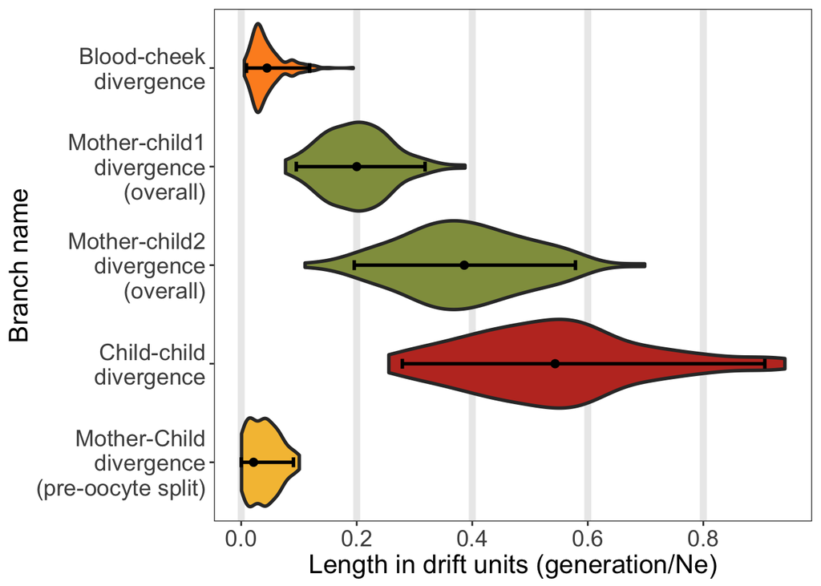

```r
#filter out pairwise divergences for now. These can be examined separately if need be.
mbls.df2<-mbls.df%>%
  filter(branch%in%c("m.tdiv","c1.tdiv","c2.tdiv","m1_c1",'m1_c2','c1_c2','m1_c'))%>%
  mutate(branch.type=case_when(branch%in%c("m.tdiv","c1.tdiv","c2.tdiv")~"tdiv",
                               branch%in%c('m1_c1')~'m1_c1',
                               branch%in%c('m1_c2')~'m1_c2',
                               branch%in%c('m1_c')~'m1_c',
                               branch%in%c('c1_c2')~'c1_c2'))

mbls.df2.ci<-mbls.df2%>%
  group_by(branch.type)%>%
  summarize(mean=mean(length),
            lower=quantile(length,probs=0.025),
            upper=quantile(length,probs=0.975))%>%
  mutate(lower=ifelse(lower<0,0,lower))

mbls.df2$branch.type<-factor(mbls.df2$branch.type,
                             levels=c("tdiv","m1_c1","m1_c2","c1_c2","m1_c"))

mbls.df2.ci$branch.type<-factor(mbls.df2.ci$branch.type,
                             levels=c("tdiv","m1_c1","m1_c2","c1_c2","m1_c"))


#plot!
plt.bls=ggplot()+
  geom_violin(data=mbls.df2,aes(branch.type,length,fill=branch.type),scale="width",trim=T,size=1)+
  geom_point(data=mbls.df2.ci,aes(branch.type,mean),size=2)+
  geom_errorbar(data=mbls.df2.ci,aes(branch.type,ymin=lower,ymax=upper),width=0.1,size=1)+
  theme_bw()+
  theme(legend.position="none",
        axis.text = element_text(size=14),
        axis.title = element_text(size=16),
        panel.grid.major.y=element_blank(),
        panel.grid.major.x=element_line(size=2),
        panel.grid.minor.x=element_blank())+
  scale_fill_manual(values=c("#fd8f24","#919c4c","#919c4c","#c03728","#f5c041"))+
  scale_y_continuous(limits=c(0,max(mbls.df2$length)),breaks=seq(0,max(mbls.df2$length),0.2))+
  labs(x="Branch name",y="Length in drift units (generation/Ne)")+
  coord_flip()+
  scale_x_discrete(limits=rev(levels(mbls.df2$branch.type)),
                   labels=c("Mother-Child\ndivergence\n(pre-oocyte split)",
                            "Child-child\ndivergence",
                            "Mother-child2\ndivergence\n(overall)",
                            "Mother-child1\ndivergence\n(overall)",
                            "Blood-cheek\ndivergence"))


# ggsave("~/Documents/mtproj_files/M2_new/files/Analysis/Branch_stats/plt_bls_phylogeny_ratio_a_avgs_04092019.pdf",
#         plt.bls,
#         height=6,
#         width=8,
#         useDingbats=F)

# fwrite(mbls.df,"~/Documents/mtproj_files/M2_new/files/Analysis/Branch_stats/bs_df_04092019.txt",
#         sep="\t",
#         col.names=T,
#         row.names=F,
#         quote=F)

plt.bls
```

BLS relies on the assumption that the heteroplasmies are polymorphic in the root of the phylogeny. In other words, we assume that if a site is heteroplasmic in one sample in the family, it must have been polymorphic at the root. To test whether BLS is sensitive to this assumption, we estimated BLS using different subsets of the data based on how many samples were heteroplasmic in the family.

We restricted this analysis only to phylogenies with a mother and 2 children only.

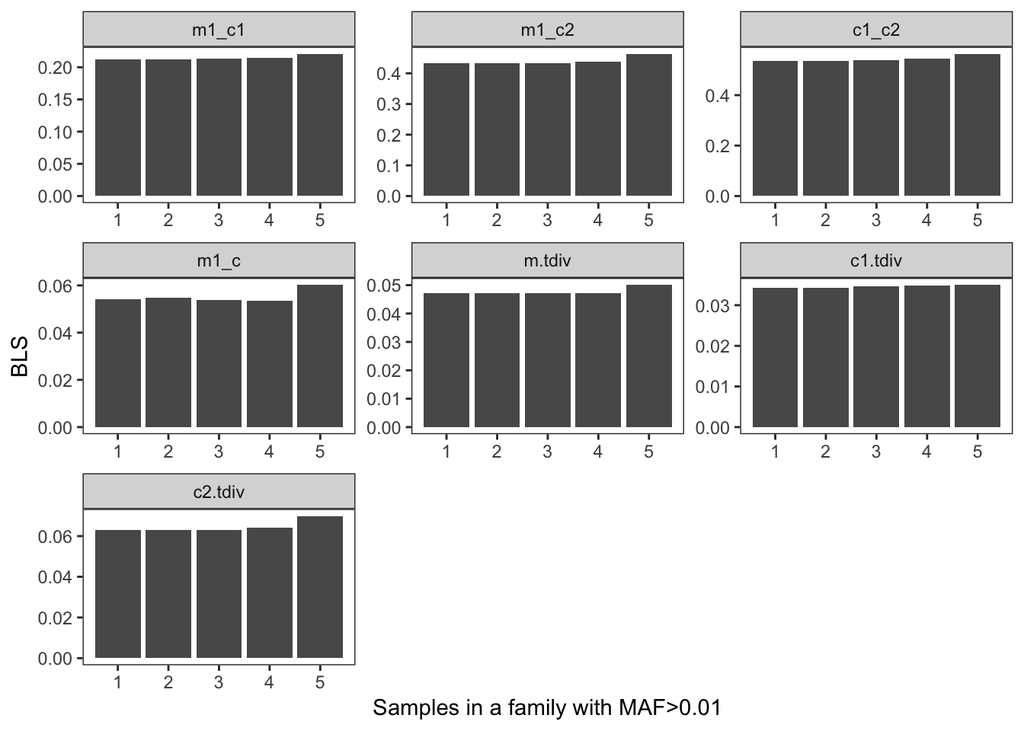

```r
#calculate bls across heteroplasmies
#filter on no. of samples in the family who are heteroplasmic
#for now only do this for 1mother -2children phylogen
blsdat1<-cal_bls(shq.fst,min.hets = 1,mot_cats = "m1c2")
blsdat2<-cal_bls(shq.fst,min.hets = 2,mot_cats="m1c2")
blsdat3<-cal_bls(shq.fst,min.hets = 3,mot_cats="m1c2")
blsdat4<-cal_bls(shq.fst,min.hets = 4,mot_cats="m1c2")
blsdat5<-cal_bls(shq.fst,min.hets = 5,mot_cats="m1c2")


blsdat<-rbind(blsdat1,blsdat2,blsdat3,blsdat4,blsdat5)
mblsdat<-melt(blsdat,id.var=c("sno","min.hets","nfams"))

mblsdat%>%
  filter(variable%in%c("m1_c1","m1_c2","m1_c","c1_c2","m.tdiv","c1.tdiv","c2.tdiv"))%>%
ggplot(.,aes(min.hets,value))+
  geom_bar(stat="identity")+
  facet_wrap(~variable,scales="free")+
  theme_bw()+
  theme(panel.grid = element_blank())+
  labs(x="Samples in a family with MAF>0.01",y="BLS")
```

Turns out, BLS estimates are pretty robust to this assumption.

Let’s output some statistics:

```r
#median and 95% CI for each branch type
print("Median and 95% CI for each branch type")
```

```
## [1] "Median and 95% CI for each branch type"
```

```r
mbls.df.ci
```

```
## # A tibble: 22 x 4
##    branch        mean   lower upper
##    <fct>        <dbl>   <dbl> <dbl>
##  1 c1_bl.c1_ch 0.0455 0.0123  0.115
##  2 c1_bl.c2_bl 0.587  0.319   0.936
##  3 c1_bl.c2_ch 0.689  0.406   1.10
##  4 c1_bl.m1_bl 0.264  0.152   0.391
##  5 c1_bl.m1_ch 0.231  0.142   0.339
##  6 c1_ch.c2_bl 0.602  0.343   0.915
##  7 c1_ch.c2_ch 0.692  0.409   1.06
##  8 c1_ch.m1_bl 0.324  0.195   0.471
##  9 c1_ch.m1_ch 0.260  0.152   0.398
## 10 c2_bl.c2_ch 0.0567 0.00668 0.130
## # ... with 12 more rows
```

```r
print("Divergence between a mother and any of her children")
```

```
## [1] "Divergence between a mother and any of her children"
```

```r
mbls.df2%>%
  filter(branch.type%in%c("m1_c1","m1_c2"))%>%
  summarize(mean=mean(length),
            lower=quantile(length,probs=0.025),
            upper=quantile(length,probs=0.975))
```

```
##        mean     lower     upper
## 1 0.2931159 0.1030653 0.5604536
```

```r
print("Divergence between a mother and her older and younger children separately")
```

```
## [1] "Divergence between a mother and her older and younger children separately"
```

```r
mbls.df2%>%
  filter(branch.type%in%c("m1_c1","m1_c2"))%>%
  group_by(branch.type)%>%
  summarize(mean=mean(length),
            lower=quantile(length,probs=0.025),
            upper=quantile(length,probs=0.975))
```

```
## # A tibble: 2 x 4
##   branch.type  mean  lower upper
##   <fct>       <dbl>  <dbl> <dbl>
## 1 m1_c1       0.200 0.0954 0.318
## 2 m1_c2       0.386 0.196  0.579
```

Let’s ask some other questions:

Q: What fraction of the amount of drift in the germline can be attributed to drift occurring before the split of two oocyte lineages?

```r
#calculate the median divergence b/w mother and child and the pre-oocyte divergence
pre_post_df<-mbls.df2%>%
  filter(branch.type%in%c("m1_c1","m1_c2","m1_c"))%>%
  mutate(branch.group=case_when(branch.type%in%c("m1_c1","m1_c2")~"m1_child_overall",
                                branch.type=="m1_c"~"m1_children_pre"))%>%
  group_by(branch.group)%>%
  dcast(sno~branch.group,value.var="length",fun.aggregate=mean)%>%
  melt(id.var="sno")%>%
  group_by(variable)%>%
  summarize(median=median(value),
            lower=quantile(value,probs=0.025),
            upper=quantile(value,probs=0.975))%>%
  mutate(lower=ifelse(lower<0,0,lower))

pre_post_df
```

```
## # A tibble: 2 x 4
##   variable         median lower  upper
##   <fct>             <dbl> <dbl>  <dbl>
## 1 m1_child_overall 0.288  0.171 0.420
## 2 m1_children_pre  0.0212 0     0.0905
```

We can calculate the % of heteroplasmy change due to drift pre-oocyte split:

```r
pre_post_df[2,-1]/pre_post_df[1,-1]
```

```
##      median lower    upper
## 1 0.0737787     0 0.215172
```

```r
#ignore the negative numbers
```

Q. Is there more drift occurring in cheek vs blood tissue?

To answer this, I will calculate the divergence b/w the blood tissues of two individuals and the divergence b/w the cheek tissues of two individuals and compare the two divergences. Because the internal branches should be the same in both cases, the only difference between the two divergences is the length of the external branches (i.e. cheek vs blood).

```r
#isolate cases where the Fst is calculated for different individuals but the tissues are the same (e.g. m1_bl.c1_bl or m1_ch.c1_ch but not m1_bl.m1_ch or m1_bl.c1_ch)

bl.ch.div<-bls.df[,c(1,grep(".._bl\\..._bl|.._ch\\..._ch",colnames(bls.df)))]

bl.ch.div%>%
  melt(id.var="sno",variable.name="pair",value.name="blength")%>%
  mutate(tissue=case_when(pair%in%c("c1_bl.m1_bl",
                                         "c2_bl.m1_bl",
                                         "c1_bl.c2_bl")~"blood",
                               pair%in%c("c1_ch.m1_ch",
                                         "c2_ch.m1_ch",
                                         "c1_ch.c2_ch")~"cheek"))%>%
  group_by(tissue)%>%
  summarize(median=median(blength),
            lower=quantile(blength,probs=0.025),
            upper=quantile(blength,probs=0.975))
```

```
## # A tibble: 2 x 4
##   tissue median lower upper
##   <chr>   <dbl> <dbl> <dbl>
## 1 blood   0.409 0.179 0.839
## 2 cheek   0.463 0.176 0.989
```

The cheek divergence appears to be slightly higher than blood divergence but not by much.

### mtDNA bottleneck size from BLS

Now let’s calculate various statistics and bottleneck size from BLS. The idea behind the latter this is simple: If heteroplasmies experience a lot of drift during germline development, the bottleneck size is likely small, and vice versa. We can use the approximation from Wilton et al. (2018) (Wilton et al. 2018) to estimate the bottleneck size $N_{b}$:

$N_{b}=2/d_{g}$

where $d_{g}$ is the amount of drift between a mother and a child

```r
#both children combined
mbls.df2%>%
  filter(branch.type%in%c("m1_c1","m1_c2"))%>%
  summarize(median=2/mean(length),
            lower=2/quantile(length,probs=0.975),
            upper=2/quantile(length,probs=0.025))
```

```
##     median    lower    upper
## 1 6.823239 3.568538 19.40517
```

The effective bottleneck size is ~7, which is very similar to previous estimates and to that from OPL.

### Comparison with OPL results

Let’s these results with the OPL (Ontegenetic Phylogeny Likelihood) method (Wilton et al. 2018).

The OPL method uses a full likelihood model to estimate drift and mutation parameters on the phylogeny

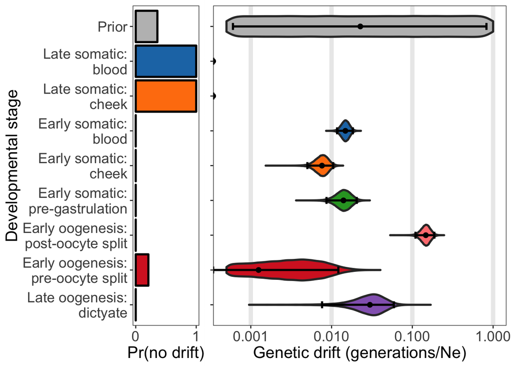

```r
#load OPL results
opl.est<-fread("~/Documents/mtproj_files/M2_new/files/Analysis/Peter_results/posterior_sample_1e5.txt",
               header=T,
               sep="\t")

#add log-uniform prior for plotting
opl.est<-opl.est%>%
  mutate(prior=rlunif(100000,
                      min=5e-04,max=1,
                      base=exp(10)))

#add P(drift=0)
prob0<-data.frame(branch=factor(c("prior","bl","ch","fblo","fbuc","som","eoo_post","eoo_pre","loo"),
                                levels=c("prior","bl","ch","fblo","fbuc","som","eoo_post","eoo_pre","loo")),
                  prob=c(0.35826,1,1,0,0,0,0,0.2092,0))

#melt dtaframe for plotting
mopl.est<-opl.est%>%
  melt(variable.name="branch",value.name="drift")

#reorder branches for plotting
mopl.est$branch<-factor(mopl.est$branch,
                        levels=c("prior","bl","ch","fblo","fbuc","som","eoo_post","eoo_pre","loo"))

#calculate 95% CI and mean
mopl.est.ci<-mopl.est%>%
  group_by(branch)%>%
  summarize(median=median(drift),
            lower=quantile(drift,probs=0.025),
            upper=quantile(drift,probs=0.975))

#plot OPL distributions
plt.opl<-ggplot()+
  geom_violin(data=mopl.est,aes(fct_rev(branch),
                                drift,fill=branch),
              trim=T,scale="width",
              width=0.6,size=1)+
  geom_point(data=mopl.est.ci,aes(fct_rev(branch),
                                  median),
             size=2)+
  geom_errorbar(data=mopl.est.ci,aes(fct_rev(branch),
                                     ymin=lower,
                                     ymax=upper),
                width=0.2,
                size=1)+
  coord_flip()+
  scale_x_discrete(labels=rev(c("Prior",
                                "Late somatic:\nblood",
                            "Late somatic:\ncheek",
                            "Early somatic:\nblood",
                            "Early somatic:\ncheek",
                            "Early somatic:\npre-gastrulation",
                            "Early oogenesis:\npost-oocyte split",
                            "Early oogenesis:\npre-oocyte split",
                            "Late oogenesis:\ndictyate")))+
  scale_y_log10(limits=c(NA,1),breaks=c(1e-4,1e-3,1e-2,1e-1,1e0))+
  theme_bw()+
  theme(legend.position="none",
        axis.text.x = element_text(size=14),
        axis.text.y=element_blank(),
        axis.title.x = element_text(size=16),
        axis.title.y=element_blank(),
        panel.grid.major.y=element_blank(),
        panel.grid.major.x=element_line(size=2),
        panel.grid.minor.x=element_blank())+
  scale_fill_manual(values=c("grey","#1f77b4","#ff7f0e","#2ca02c","#ff8080","#d62728","#9467bd"))+
  labs(y="Genetic drift (generations/Ne)",x="Developmental stage")

#plot P(drift=0) barplots
plt.bar<-ggplot()+
  geom_bar(data=prob0,aes(fct_rev(branch),prob,fill=branch),stat="identity",color="black",size=1)+
  coord_flip()+
  scale_x_discrete(labels=rev(c("Prior",
                                "Late somatic:\nblood",
                                "Late somatic:\ncheek",
                                "Early somatic:\nblood",
                                "Early somatic:\ncheek",
                                "Early somatic:\npre-gastrulation",
                                "Early oogenesis:\npost-oocyte split",
                                "Early oogenesis:\npre-oocyte split",
                                "Late oogenesis:\ndictyate")))+
  scale_y_continuous(breaks=c(0,1))+
  scale_fill_manual(values=c("grey","#1f77b4","#ff7f0e","#1f77b4","#ff7f0e","#2ca02c","#ff8080","#d62728","#9467bd"))+
  theme_bw()+
  theme(legend.position="none",
        axis.text = element_text(size=14),
        axis.title = element_text(size=16),
        panel.grid.major.y=element_blank(),
        panel.grid.major.x=element_blank(),
        panel.grid.minor.x=element_blank())+
  labs(y="Pr(no drift)",x="Developmental stage")

plt.merged<-arrangeGrob(plt.bar,plt.opl,nrow=1,ncol=2,widths=c(2,3))

# ggsave("~/Documents/mtproj_files/M2_new/files/Analysis/Branch_stats/plt_opl_phylogeny_04092019.pdf",plt.merged,height=6,width=8,useDingbats=F)

plot(plt.merged)
```

The results from OPL are qualitatively very similar to the results from BLS. We can draw the same conclusions. However, they are nor directly comparable to each other because of various reasons. See main text for this.

### Age effects using BLS

#### Tissue divergence ~ age at collection

```r
#bootstrap heteroplasmies and calculate tissue divergence for different age groups

#fst calculate across heteroplasmies in a bootstrapped samples using ratio of averages


bls_age_c.list=list()
#pb<-txtProgressBar(min=0,max=100,style=3)
for(i in 1:100){
  #sample 2 kids from multi-kid families
  #standardize mother child naming (e.g. g1-m1 -> m1-c1)
  #also recode each pairwise distance to a specific branch type
  shq.fst.tmp2<-lapply(shq.fst,sample2kids)

  #sample heteroplasmies with replacement
  shq.fst.tmp3<-boot.hets(shq.fst.tmp2)

  bls_age_c.list[[i]]<-cal_bls_age_c(shq.fst.tmp3)
  #setTxtProgressBar(pb,i)
}

#convert list of dfs to a single df
bls_age_c.df<-bind_rows(bls_age_c.list,.id="sno")


#calculate median and 95% CI
mbls_age_c_ci<-bls_age_c.df%>%
  group_by(age_collection)%>%
  summarize(median=median(length),
            lower=quantile(length,0.025),
            upper=quantile(length,0.975))

mbls_age_c_ci
```

```
## # A tibble: 2 x 4
##   age_collection median   lower  upper
##   <ord>           <dbl>   <dbl>  <dbl>
## 1 [0.0932,11.8]  0.0481 0.00790 0.132
## 2 (11.8,87]      0.0344 0.0192  0.0504
```

Plot tissue divergence by age of individual at collection.

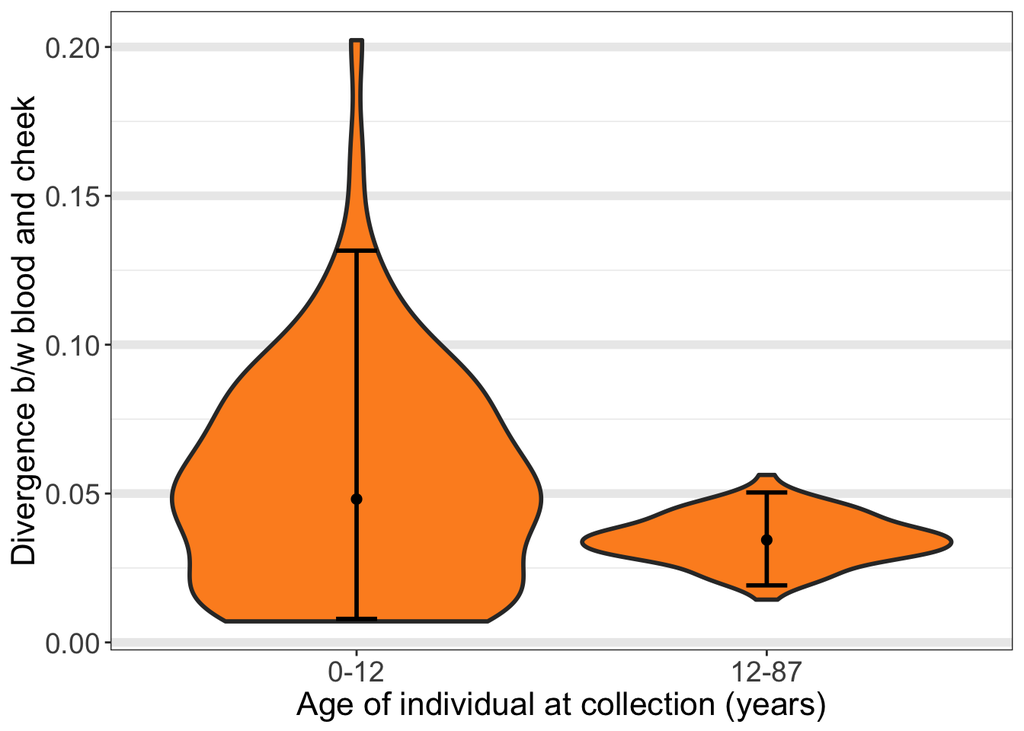

```r
plt.age_div<-ggplot()+
  geom_violin(data=bls_age_c.df,aes(age_collection,length),scale="width",trim=T,size=1,fill="#fd8f24")+
  geom_point(data=mbls_age_c_ci,aes(age_collection,median),size=2)+
  geom_errorbar(data=mbls_age_c_ci,aes(age_collection,ymin=lower,ymax=upper),width=0.1,size=1)+
  theme_bw()+
  theme(panel.grid.major.x = element_blank(),
        panel.grid.major.y = element_line(size=2),
        axis.text=element_text(size=14),
        axis.title=element_text(size=16))+
  labs(x="Age of individual at collection (years)",y="Divergence b/w blood and cheek")+
  scale_x_discrete(labels=c("0-12","12-87"))

# fwrite(bls_age_c.df,"~/Documents/mtproj_files/M2_new/files/Analysis/Branch_stats/dat_bls_agec_bootstrap.txt",sep="\t",col.names=T,row.names=F,quote=F)

#save plot to pdf
# ggsave("~/Documents/mtproj_files/M2_new/files/Analysis/Branch_stats/plt_bls_tdiv_age_collection_040952019.pdf",plt.age_div,height=6,width=8,useDingbats=F)

plt.age_div
```

Calculate the divergence b/w tissues per individual (no bootstrap, average across heteroplasmies for each individual)

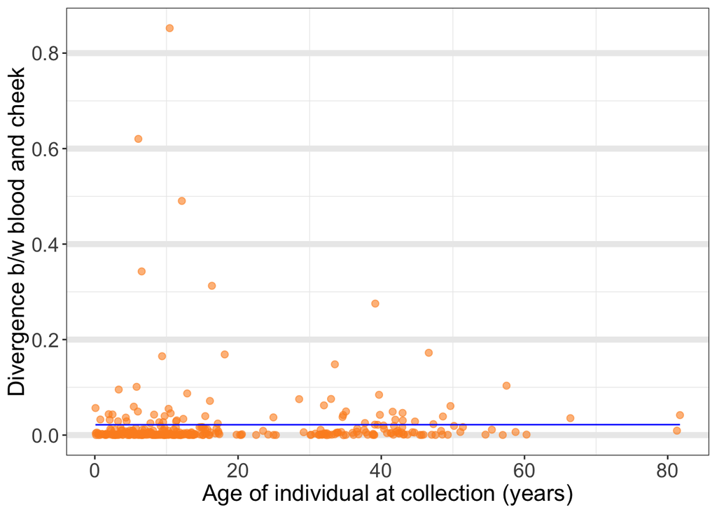

```r
#calculate blood-tissue divergence between tissues with no bootstrap
bls_agec_noboot<-cal_bls_age_c(shq.fst,bootstrap=FALSE)

#summary stats
bls_agec_noboot2<-bls_agec_noboot%>%
  filter(is.na(length)==FALSE)
lm.bls_agec<-lm(data=bls_agec_noboot2,length~age_collection)
beta.bls_agec<-summary(lm.bls_agec)$coefficients[2]
p.bls_agec<-summary(lm.bls_agec)$coefficients[8]
bls_agec_noboot2$lm_pred<-predict(lm.bls_agec)

plt.agec_noboot<-ggplot(data=bls_agec_noboot2,aes(age_collection,length))+
  geom_point(size=2,color="#fd8f24",alpha=0.6)+
  theme_bw()+
  theme(panel.grid.major.x = element_blank(),
        panel.grid.major.y = element_line(size=2),
        axis.text=element_text(size=14),
        axis.title=element_text(size=16))+
  labs(x="Age of individual at collection (years)",y="Divergence b/w blood and cheek")+
  geom_line(aes(age_collection,lm_pred),color="blue")



plt.agec_noboot
```

Older people don’t tend to have more highly diverged tissue samples in terms of heteroplasmy frequency (95% CIs overlap). This is somewhat surprising because the time since the divergence between blood and cheek is probably the longest period in the phylogeny in absolute time.

#### Mother-child divergence ~ age at birth

Next, I tested whether the divergence between older mothers and their children is higher than the divergence between younger mothers and their kids. This would be expected if there was drift in heteroplasmy frequency during meiotic arrest.

```r
#######quartiles for mother's age at birth of child#################
#[1] (25.1,29.7] [15.4,25.1] (29.7,33.5] (33.5,46.2]

#assign each child a number 1,2 based onage quartile to which they belong
shq.fst.tmp2<-lapply(shq.fst,function(fst.obj){
  mot_cat=unique(fst.obj$mot_cat)
  if(mot_cat%in%c("m1c2","m1c3","m1c4","m1c5")){
    fst.obj.tmp<-fst.obj%>%
      filter((ind1==ind2) | (ind1%in%c("c1","c2","c3","c4","c5")&ind2=="m1"))%>%
        mutate(ind1=case_when(age.b1.cat=="[15.4,29.3]"~"c1",
                              age.b1.cat=="(29.3,46.2]"~"c2",
                              TRUE~"m1"),
               ind2=case_when(age.b2.cat=="[15.4,29.3]"~"c1",
                              age.b2.cat=="(29.3,46.2]"~"c2",
                              TRUE~"m1"))%>%
        mutate(pair=paste(ind1,"_",tis1,".",ind2,"_",tis2,sep=""))
  }
  if(mot_cat%in%c("g1m2","g1m1")){
    fst.obj.tmp<-fst.obj%>%
      filter((ind1==ind2) | (ind1==c("g1") & ind2%in%c("m1","m2")))%>%
      mutate(ind1=case_when(age.b1.cat=="[15.4,29.3]"~"c1",
                            age.b1.cat=="(29.3,46.2]"~"c2",
                            TRUE~"m1"),
             ind2=case_when(age.b1.cat=="[15.4,29.3]"~"c1",
                            age.b1.cat=="(29.3,46.2]"~"c2",
                            TRUE~"m1"))%>%
      mutate(pair=paste(ind2,"_",tis2,".",ind1,"_",tis1,sep=""))
  }
  if(mot_cat%in%c("t1g1","t1g2")){
    fst.obj.tmp<-fst.obj%>%
      filter((ind1==ind2) | (ind1==c("g1") & ind2%in%c("m1","m2")))%>%
      mutate(ind1=case_when(age.b1.cat=="[15.4,29.3]"~"c1",
                            age.b1.cat=="(29.3,46.2]"~"c2",
                            TRUE~"m1"),
             ind2=case_when(age.b1.cat=="[15.4,29.3]"~"c1",
                            age.b1.cat=="(29.3,46.2]"~"c2",
                            TRUE~"m1"))%>%
      mutate(pair=paste(ind1,"_",tis1,".",ind2,"_",tis2,sep=""))
  }
  return(fst.obj.tmp)
})


#bootstrap heteroplasmies and calculate mother-child divergence for different age groups
#fst calculate across heteroplasmies in a bootstrapped samples using ratio of averages
bls_age_b.list=list()
#pb<-txtProgressBar(min=0,max=100,style=3)
for(i in 1:100){
  #sample list w/t replacement
  shq.fst.tmp3<-boot.hets(shq.fst.tmp2)


  bls_age_b.list[[i]]<-cal_bls_age_b1(shq.fst.tmp3)
  #setTxtProgressBar(pb,i)
}

#convert list of dfs to a single df
bls_age_b.df<-bind_rows(bls_age_b.list,.id="sno")


#calculate median and 95% CI
mbls_age_b.df.ci<-bls_age_b.df%>%
  group_by(m_c)%>%
  summarize(median=median(length),lower=quantile(length,0.025),upper=quantile(length,0.975))

mbls_age_b.df.ci
```

```
## # A tibble: 2 x 4
##   m_c   median  lower upper
##   <fct>  <dbl>  <dbl> <dbl>
## 1 m1_c1 0.0779 0.0153 0.194
## 2 m1_c2 0.368  0.256  0.561
```

Plot mother-child divergence by age of mother at child birth

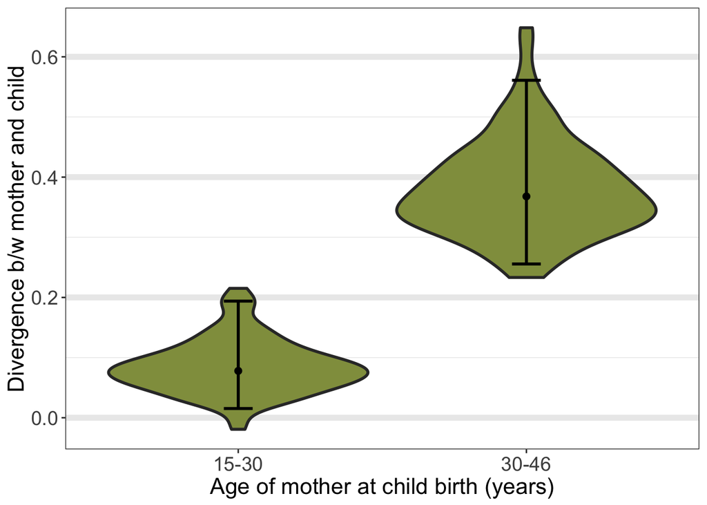

```r
plt.age_div<-ggplot()+
  geom_violin(data=bls_age_b.df,aes(m_c,length),scale="width",trim=T,size=1,fill="#919c4c")+
  geom_point(data=mbls_age_b.df.ci,aes(m_c,median),size=2)+
  geom_errorbar(data=mbls_age_b.df.ci,aes(m_c,ymin=lower,ymax=upper),width=0.1,size=1)+
  theme_bw()+
  theme(panel.grid.major.x = element_blank(),
        panel.grid.major.y = element_line(size=2),
        axis.text=element_text(size=14),
        axis.title=element_text(size=16))+
  labs(x="Age of mother at child birth (years)",y="Divergence b/w mother and child")+
  scale_x_discrete(labels=c("15-30","30-46"))

# fwrite(bls_age_b.df,"~/Documents/mtproj_files/M2_new/files/Analysis/Branch_stats/dat_bls_ageb_bootstrap.txt",sep="\t",col.names=T,row.names=F,quote=F)
#
# #save plot to pdf
# ggsave("~/Documents/mtproj_files/M2_new/files/Analysis/Branch_stats/plt_bls_mcdiv_age_birth_04092019.pdf",plt.age_div,height=6,width=8,useDingbats=F)

plt.age_div
```

This is an interesting result as it shows that the mother-child divergence is greater for older mothers than for younger mothers. This suggests that there is drift occurring in heteroplasmy frequency during meiotic arrest (as it is the only age-dependent stage in the germ line).

### Selection tests using BLS

The branch statistic methods (LSBL (Shriver et al. 2004), PBS (Yi et al. 2010), and ABS (Cheng, Xu, and DeGiorgio 2017)) were designed to test for selection. Let’s use BLS to do the same with heteroplasmy data. The point is to divide heteroplasmies into categories based on their function or impact (synonymous/non-synonymous) and test whether some categories exhibit more drift than others.

Let’s calculate BLS for synonymous and non-synonymous mutations first. Tabulate number of synonymous/non-synonymous heteroplasmies as well as coding/non-coding heteroplasmies

```r
#tabulate how many heteroplasmies are synonymous vs non-synonymous and how many are non-coding
syn.tally<-bind_rows(shq.fst)%>%
  distinct(mother_group,syn)%>%
  mutate(syn=ifelse(syn=="","non-cds",syn))%>%
  group_by(syn)%>%
  count()

syn.tally
```

```
## # A tibble: 4 x 2
## # Groups:   syn [4]
##   syn         n
##   <chr>   <int>
## 1 non-cds   155
## 2 nsyn      123
## 3 syn        77
## 4 <NA>        3
```

```r
####calculate BLS for syn/nonsyn mutations
#permutation test for synonymous-non-synonymous sites
shq.fst.coding<-shq.fst%>%keep(function(x){x$syn[1]!=""})

shq_fst_syn<-shq.fst%>%keep(function(x){x$syn[1]=="syn"})
shq_fst_nsyn<-shq.fst%>%keep(function(x){x$syn[1]=="nsyn"})

#create empty list to populate results for each df
bls_syn.perm.list=list()
bls_nsyn.perm.list=list()
#generate random vector of syn/nsyn annotation based on tally
#there are 200 coding heteroplasmies
#sample 123 non-synonymous heteroplasmies
#pb<-txtProgressBar(min=0,max=100,style=3)
for(i in 1:100){

  #sample 2 kids from multi-kid families
  #standardize mother child naming (e.g. g1-m1 -> m1-c1)
  #also recode each pairwise distance to a specific branch type
  shq_fst_syn1<-lapply(shq_fst_syn,sample2kids)
  shq_fst_nsyn1<-lapply(shq_fst_nsyn,sample2kids)

  #subsample non-synonymous heteroplasmies
  #to match synonymous heteroplasmies
  shq_fst_nsyn1.1<-sample(shq_fst_nsyn1,77,replace=F)

  shq_fst_coding1<-c(shq_fst_nsyn1.1,shq_fst_syn1)

  #totaling 154 heteroplasmies
  #artificially create 77 synonymous heteroplasmies
  #and 77 non-synonymous heteroplasmies
  nsyn_ix=sample(154,77,replace=F)
  syn_ix=setdiff(seq(1,154),nsyn_ix)
  shq_fst_syn2<-shq_fst_coding1[syn_ix]
  shq_fst_nsyn2<-shq_fst_coding1[nsyn_ix]

  #change synonymous labels
  shq_fst_syn2<-lapply(shq_fst_syn2,function(x){
    x$syn<-"syn"
    return(x)
  })
  shq_fst_nsyn2<-lapply(shq_fst_nsyn2,function(x){
    x$syn<-"nsyn"
    return(x)
  })

  bls_syn.perm.list[[i]]<-cal_bls_syn(shq_fst_syn2)
  bls_nsyn.perm.list[[i]]<-cal_bls_syn(shq_fst_nsyn2)
  #setTxtProgressBar(pb,i)

}

bls_syn.perm.df<-bind_rows(bls_syn.perm.list,.id="sno")
bls_nsyn.perm.df<-bind_rows(bls_nsyn.perm.list,.id="sno")
bls_synall.perm.df<-rbind(bls_syn.perm.df,bls_nsyn.perm.df)

mbls.syn.perm.df.ci<-bls_synall.perm.df%>%
  group_by(syn,branch.type)%>%
  summarize(median=median(length),
            lower=quantile(length,probs=0.025),
            upper=quantile(length,probs=0.975))%>%
  mutate(lower=ifelse(lower<0,0,lower))

bls_syn.perm.merged<-merge(bls_syn.perm.df,bls_nsyn.perm.df,by=c("sno","branch","branch.type"))
bls_syn.perm.merged<-bls_syn.perm.merged%>%
  mutate(diff=length.x-length.y)%>%
  group_by(sno,branch.type)%>%
  summarize(diff=mean(diff))

mbls.syn_diff.perm.ci<-bls_syn.perm.merged%>%
  group_by(branch.type)%>%
  summarize(median=median(diff),
            lower=quantile(diff,probs=0.025),
            upper=quantile(diff,probs=0.975))

#calculate observed values of difference in branch length between syn and nsyn
shq_fst_syn.obs<-lapply(shq_fst_syn,sample2kids)
shq_fst_nsyn.obs<-lapply(shq_fst_nsyn,sample2kids)

bls_syn.obs<-cal_bls_syn(shq_fst_syn.obs)
bls_nsyn.obs<-cal_bls_syn(shq_fst_nsyn.obs)

bls_syn.obs<-bls_syn.obs%>%
  group_by(branch.type)%>%
  summarize(length=mean(length))

bls_nsyn.obs<-bls_nsyn.obs%>%
  group_by(branch.type)%>%
  summarize(length=mean(length))

bls_syn.obs.merged<-merge(bls_syn.obs,bls_nsyn.obs,by=c("branch.type"))
bls_syn.obs.merged<-bls_syn.obs.merged%>%
  mutate(diff=length.x-length.y)

#calculate p-values
bls_syn.obs.merged$pvalue<-NA
for(i in 1:5){
  branch.name=bls_syn.obs.merged$branch.type[i]
  #observed value
  obs.diff<-bls_syn.obs.merged%>%
    filter(branch.type==branch.name)%>%
    pull(diff)
  permdiff<-bls_syn.perm.merged%>%
    filter(branch.type==branch.name)%>%
    pull(diff)
  bls_syn.obs.merged$pvalue[i]<-length(which(permdiff>obs.diff))/length(permdiff)
}

bls_syn.obs.merged<-bls_syn.obs.merged%>%
  mutate(direction=case_when(diff<0~"down",
                             diff>0~"up"))
```

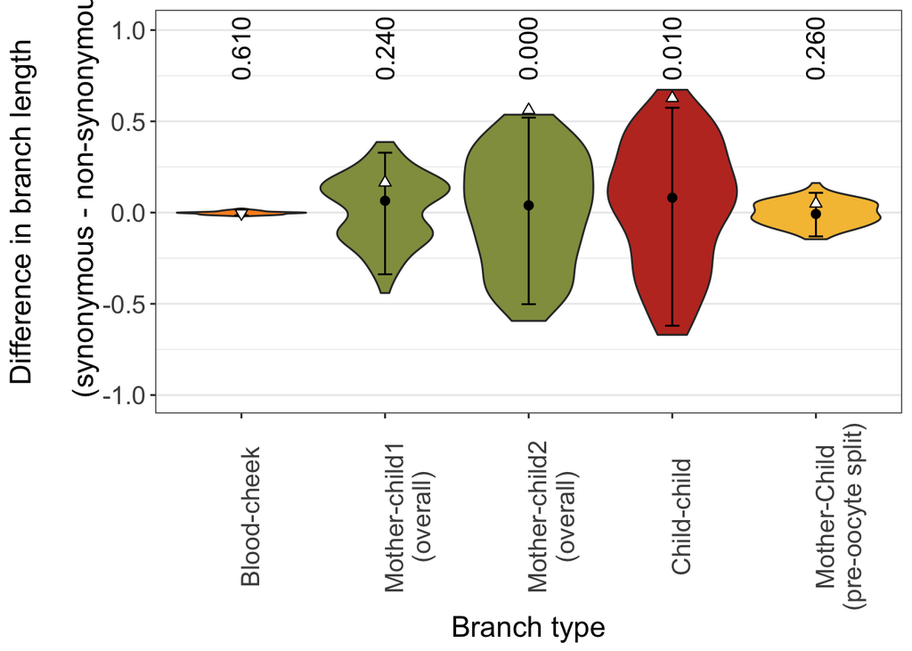

```r
#plot syn-nsyn difference
plt_bls_syndiff.perm<-ggplot(bls_syn.perm.merged)+
  geom_violin(scale="width",
              trim=T,
              aes(branch.type,
                  diff,
                  fill=branch.type))+
  geom_point(data=mbls.syn_diff.perm.ci,
             aes(branch.type,median),
             size=2)+
  geom_errorbar(data=mbls.syn_diff.perm.ci,
                aes(branch.type,ymin=lower,ymax=upper),
                width=0.1,
                size=0.5)+
  theme_bw()+
  theme(axis.text.x = element_text(angle=90),
        legend.position="none",
        axis.text = element_text(size=14),
        axis.title = element_text(size=16),
        panel.grid.major.x=element_blank(),
        panel.grid.minor.x=element_blank())+
  labs(x="Branch type",y="Difference in branch length\n
       (synonymous - non-synonymous)")+
  geom_point(data=bls_syn.obs.merged,aes(x=branch.type,
                                         y=diff,
                                         shape=direction),
             color="black",
             fill="white",
             stroke=0.5,
             size=2)+
  scale_fill_manual(values=c("#fd8f24","#919c4c","#919c4c","#c03728","#f5c041"))+
    scale_x_discrete(labels=c("Blood-cheek",
                              "Mother-child1\n(overall)",
                              "Mother-child2\n(overall)",
                              "Child-child",
                              "Mother-Child\n(pre-oocyte split)"))+
  geom_text(data=bls_syn.obs.merged,aes(x=branch.type,
                                        y=0.9,
                                        label=format(round(pvalue,
                                                           digits=3),
                                                     nsmall=3)),
            size=14/2.8,
            angle=90)+
  scale_shape_manual(values=c(25,24))+
  ylim(c(-1,1.01))

# fwrite(bls_syn.perm.merged,"~/Documents/mtproj_files/M2_new/files/Analysis/Branch_stats/dat_bls_synperm_04092018.txt",sep="\t",col.names=F,quote=F)
#
# ggsave("~/Documents/mtproj_files/M2_new/files/Analysis/Branch_stats/plt_bls_synperm_04092019.pdf",
#        plt_bls_syndiff.perm,
#        height=7,
#        width=6,
#        useDingbats=F)

plt_bls_syndiff.perm
```

The plot shows that the branches for synonymous heteroplasmies are longer than the branches for non-synonymous heteroplasmies, particularly in the germline. This suggests that synonymous heteroplasmies experience more drift relative to non-synonymous heteroplasmies, likely because negative selection prevents non-synoymous heteroplasmies from drifting to very high frequencies.

Now let’s calculate BLS for pathogenic/non-pathogenic mutations. Tally number of pathogenic and non-pathogenic heteroplasmies.

```r
#tabulate how many heteroplasmies are synonymous vs non-synonymous and how many are non-coding
pat.tally<-bind_rows(shq.fst)%>%
  distinct(mother_group,pathogenicity)%>%
  group_by(pathogenicity)%>%
  count()

pat.tally
```

```
## # A tibble: 3 x 2
## # Groups:   pathogenicity [3]
##   pathogenicity     n
##   <chr>         <int>
## 1 N               321
## 2 P                34
## 3 <NA>              3
```

There are 34 pathogenic heteroplasmies and 321 neutal heteroplasmies. Bootstrap and generate BLS distribution for each.

```r
shq_fst_pat<-shq.fst%>%keep(function(x){x$pathogenicity[1]=="P"})
shq_fst_npat<-shq.fst%>%keep(function(x){x$pathogenicity[1]=="N"})

#create empty list to populate results for each df
bls_pat.perm.list=list()
bls_npat.perm.list=list()

#pb<-txtProgressBar(min=0,max=100,style=3)
for(i in 1:100){

  #sample 2 kids from multi-kid families
  #standardize mother child naming (e.g. g1-m1 -> m1-c1)
  #also recode each pairwise distance to a specific branch type
  shq_fst_pat1<-lapply(shq_fst_pat,sample2kids)
  shq_fst_npat1<-lapply(shq_fst_npat,sample2kids)

  #subsample non-pathogenic heteroplasmies
  #to match number of pathogenic heteroplasmies
  shq_fst_npat1.1<-sample(shq_fst_npat1,34,replace=F)

  shq_fst_pat2<-c(shq_fst_npat1.1,shq_fst_pat1)

  #totaling 62 heteroplasmies
  #artificially create 31 pathogenic heteroplasmies
  #and 31 non-pathogenic heteroplasmies
  #by shuffling labels
  npat_ix=sample(68,34,replace=F)
  pat_ix=setdiff(seq(1,68),npat_ix)
  shq_fst_pat3<-shq_fst_pat2[pat_ix]
  shq_fst_npat3<-shq_fst_pat2[npat_ix]

  #change pathogenicity labels
  shq_fst_pat3<-lapply(shq_fst_pat3,function(x){
    x$pathogenicity<-"P"
    return(x)
  })
  shq_fst_npat3<-lapply(shq_fst_npat3,function(x){
    x$pathogenicity<-"N"
    return(x)
  })

  bls_pat.perm.list[[i]]<-cal_bls_pat(shq_fst_pat3)
  bls_npat.perm.list[[i]]<-cal_bls_pat(shq_fst_npat3)
  #setTxtProgressBar(pb,i)

}

bls_pat.perm.df<-bind_rows(bls_pat.perm.list,.id="sno")
bls_npat.perm.df<-bind_rows(bls_npat.perm.list,.id="sno")


bls_pat.perm.merged<-merge(bls_npat.perm.df,bls_pat.perm.df,by=c("sno","branch","branch.type"))
bls_pat.perm.merged<-bls_pat.perm.merged%>%
  mutate(diff=length.x-length.y)%>%
  group_by(sno,branch.type)%>%
  summarize(diff=mean(diff))

mbls.pat_diff.perm.ci<-bls_pat.perm.merged%>%
  group_by(branch.type)%>%
  summarize(median=median(diff),
            lower=quantile(diff,probs=0.025),
            upper=quantile(diff,probs=0.975))

#calculate observed values of difference in branch length between pathogenic and non-pathogenic
shq_fst_pat.obs<-lapply(shq_fst_pat,sample2kids)
shq_fst_npat.obs<-lapply(shq_fst_npat,sample2kids)

bls_pat.obs<-cal_bls_pat(shq_fst_pat.obs)
bls_npat.obs<-cal_bls_pat(shq_fst_npat.obs)

bls_pat.obs<-bls_pat.obs%>%
  group_by(branch.type)%>%
  summarize(length=mean(length))

bls_npat.obs<-bls_npat.obs%>%
  group_by(branch.type)%>%
  summarize(length=mean(length))

bls_pat.obs.merged<-merge(bls_npat.obs,bls_pat.obs,by=c("branch.type"))
bls_pat.obs.merged<-bls_pat.obs.merged%>%
  mutate(diff=length.x-length.y)

#calculate p-values
bls_pat.obs.merged$pvalue<-NA
for(i in 1:5){
  branch.name=bls_pat.obs.merged$branch.type[i]
  #observed value
  obs.diff<-bls_pat.obs.merged%>%
    filter(branch.type==branch.name)%>%
    pull(diff)
  permdiff<-bls_pat.perm.merged%>%
    filter(branch.type==branch.name)%>%
    pull(diff)
  bls_pat.obs.merged$pvalue[i]<-length(which(permdiff>obs.diff))/length(permdiff)
}

bls_pat.obs.merged<-bls_pat.obs.merged%>%
  mutate(direction=case_when(diff<0~"down",
                             diff>0~"up"))
```

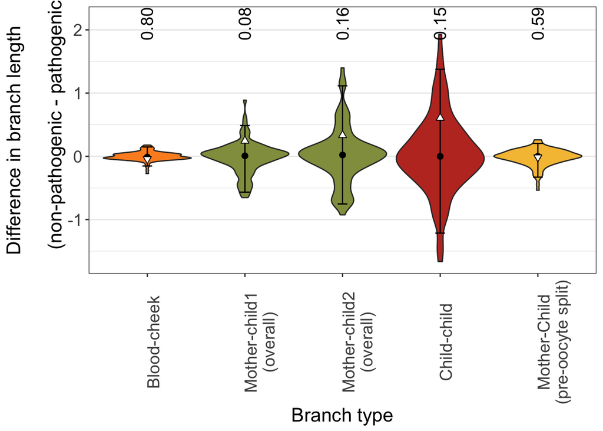

```r
#plot
plt_bls_patdiff.perm<-ggplot(bls_pat.perm.merged)+
  geom_violin(scale="width",
              trim=T,
              aes(branch.type,diff,fill=branch.type))+
  geom_point(data=mbls.pat_diff.perm.ci,
             aes(branch.type,median),
             size=2)+
  geom_errorbar(data=mbls.pat_diff.perm.ci,
                aes(branch.type,ymin=lower,ymax=upper),
                width=0.1,
                size=0.5)+
  theme_bw()+
  theme(axis.text.x = element_text(angle=90),
        legend.position="none",
        axis.text = element_text(size=14),
        axis.title = element_text(size=16),
        panel.grid.major.x=element_blank(),
        panel.grid.minor.x=element_blank())+
  labs(x="Branch type",y="Difference in branch length\n
       (non-pathogenic - pathogenic)")+
  geom_point(data=bls_pat.obs.merged,aes(branch.type,
                                         diff,
                                         shape=direction),
             color="black",
             fill="white",
             stroke=0.5,
             size=2)+
  scale_fill_manual(values=c("#fd8f24","#919c4c","#919c4c","#c03728","#f5c041"))+
  scale_x_discrete(labels=c("Blood-cheek",
                            "Mother-child1\n(overall)",
                            "Mother-child2\n(overall)",
                            "Child-child",
                            "Mother-Child\n(pre-oocyte split)"))+
  geom_text(data=bls_pat.obs.merged,aes(
    x=branch.type,
    y=max(bls_pat.perm.merged$diff)+0.25,
    label=format(round(pvalue,
                       digits=3),
                 nsmall=3)),
    size=14/2.8,
    angle=90)+
  scale_shape_manual(values=c(25,24))




# ggsave("~/Documents/mtproj_files/M2_new/files/Analysis/Branch_stats/plt_bls_patperm_04092019.pdf",
#        plt_bls_patdiff.perm,
#        height=7,
#        width=6,
#        useDingbats=F)

# fwrite(bls_pat.perm.merged,"~/Documents/mtproj_files/M2_new/files/Analysis/Branch_stats/dat_blspat_perm_04092019.txt",sep="\t",col.names=T,row.names=F,quote=F)


plt_bls_patdiff.perm
```

Even though we see a similar pattern here, i.e., non-pathogenic heteroplasmies experience more drift relative to pathogenic heteroplasmies, the difference is not as significant. This might be because pathogenic heteroplasmies are already present at very low frequencies, potentially below a threshold at which selection might operate.

### References

Bhatia, Gaurav, Nick Patterson, Sriram Sankararaman, and Alkes L Price. 2013. “Estimating and interpreting FST: the impact of rare variants.” *Genome Research* 23 (9): 1514–21. https://doi.org/10.1101/gr.154831.113.

Cheng, Xiaoheng, Cheng Xu, and Michael DeGiorgio. 2017. “Fast and robust detection of ancestral selective sweeps.” *Molecular Ecology*. https://doi.org/10.1111/mec.14416.

Shriver, Mark D, Giulia C Kennedy, Esteban J Parra, Heather A Lawson, Vibhor Sonpar, Jing Huang, Joshua M Akey, and Keith W Jones. 2004. “The genomic distribution of population substructure in four populations using 8,525 autosomal SNPs.” *Human Genomics* 1 (4): 274. https://doi.org/10.1186/1479-7364-1-4-274.

Wilton, Peter R., Arslan Zaidi, Kateryna Makova, and Rasmus Nielsen. 2018. “A population phylogenetic view of mitochondrial heteroplasmy.” *Genetics* 208 (3): 1261–74. https://doi.org/10.1534/genetics.118.300711.

Yi, Xin, Yu Liang, Emilia Huerta-Sanchez, Xin Jin, Zha Xi Ping Cuo, John E. Pool, N. Xu, et al. 2010. “Sequencing of 50 human exomes reveals adaptation to high altitude.” *Science* 329 (5987): 75–78. https://doi.org/10.1126/science.1190371.